# Titanic

## Titanic: Machine Learning from Disaster

泰坦尼克号是kaggle上用于学习的初级项目是一个二分类问题，可以用于初步了解机器学习的思想。

## 数据集初步分析

- PassengerId： 乘客Id，个人认为这个特征没什么用
- Survived： 标签属性，这个属性就是需要预测的属性
- Pclass： Ticket class —— 船票类型，经济地位的象征
- Name： 名字，又一个没用的属性，运气和名字有关系吗？上了泰坦尼克的都挺倒霉的
- Sex： 性别
- Age： 年龄
- SibSp： 泰坦尼克号上的兄弟姐妹/配偶
- Parch： 泰坦尼克号上的父母/孩子
- Ticket： 票号，这一项是有重复的，可能存在连票几个人一样的票号，但是经过初步观察，相同票号通常在上两个特征上有较大的关联（兄弟姐妹、配偶、子女），虽然可能存在未婚夫、二奶等情况，但还是觉得会被淹没在其他特征当中，神经网络就应该突出关键特征不是么？所以这个特征很可能没什么用。
- Fare： 乘客票价
- Cabin： 客舱号码
- Embarked： 登船港口

```python
import pandas
import tensorflow as tf
import numpy as np
```

```python
class GetData:
    """
    获取数据集
    """
    def __init__(self):
        # 训练数据
        train_data = pandas.read_csv('train.csv')
        # print(train_data.info())
        '''共891条数据，但是
        Age            714 non-null float64
        Cabin          204 non-null object
        Embarked       889 non-null object
        这三项存在缺失
        '''
        train_data.loc[train_data['Sex']=='male','Sex'] = 0   # 性别，男性为0，女性为1
        train_data.loc[train_data['Sex']=='female','Sex'] = 1
        train_data['Embarked'] = train_data['Embarked'].fillna(0) # 登船港口数据存在缺失 缺失：0 S:1,C:2,Q:3
        train_data.loc[train_data['Embarked']=='S','Embarked'] = 1
        train_data.loc[train_data['Embarked']=='C','Embarked'] = 2
        train_data.loc[train_data['Embarked']=='Q','Embarked'] = 3

        # 对于船舱，训练集缺失太多，所以将缺失数据统一填充为0，而船舱分类也太多，暂且全部赋值为1
        train_data['Cabin'] = train_data['Cabin'].fillna(0)
        train_data.loc[train_data['Cabin']!=0,'Cabin'] = 1

        train_data['Age'] = train_data['Age'].fillna(train_data['Age'].median())

        self.train_original_X = train_data.loc[:,[
            'Pclass','Sex','Age','SibSp','Parch','Fare','Cabin','Embarked',
        ]]
        train_data['UnSurvived'] = train_data.loc[:,['Survived']]
        train_data.loc[train_data['Survived']==1,'UnSurvived'] = 0
        train_data.loc[train_data['Survived']==0,'UnSurvived'] = 1
        self.train_original_Y = train_data.loc[:,['Survived','UnSurvived']]
        # print(train_data.info())
        # print(self.train_original_X.info())
        # print(self.train_original_X.head(5))
        # print(self.train_original_Y.info())
        # print(self.train_original_Y.head(5))
        # print('------init--------',np.shape(self.train_original_Y))

        # 测试数据
        test_data = pandas.read_csv('test.csv')
        # print(test_data.info())
        '''
        Age            332 non-null float64
        Fare           417 non-null float64
        Cabin          91 non-null object
        这三项存在缺失
        '''
        test_data.loc[test_data['Sex']=='male','Sex'] = 0   # 性别，男性为0，女性为1
        test_data.loc[test_data['Sex']=='female','Sex'] = 1
        test_data['Fare'] = test_data['Fare'].fillna(test_data['Fare'].median()) # 平均数弥补 Fare 票价 缺失数据
        test_data.loc[test_data['Embarked']=='S','Embarked'] = 1 # 登船港口数据存在缺失 缺失：0 S:1,C:2,Q:3
        test_data.loc[test_data['Embarked']=='C','Embarked'] = 2
        test_data.loc[test_data['Embarked']=='Q','Embarked'] = 3

        # 对于船舱，训练集缺失太多，所以将缺失数据统一填充为0，而船舱分类也太多，暂且全部赋值为1
        test_data['Cabin'] = test_data['Cabin'].fillna(0)
        test_data.loc[test_data['Cabin']!=0,'Cabin'] = 1

        test_data['Age'] = test_data['Age'].fillna(test_data['Age'].median())
        # print(test_data.info())
        self.test_original_X = test_data.loc[:,[
            'Pclass','Sex','Age','SibSp','Parch','Fare','Cabin','Embarked',
        ]]

        test_data = pandas.read_csv('gender_submission.csv')
        test_data['UnSurvived'] = test_data.loc[:,['Survived']]
        test_data.loc[test_data['Survived']==1,'UnSurvived'] = 0
        test_data.loc[test_data['Survived']==0,'UnSurvived'] = 1
        self.test_original_Y = test_data.loc[:,['Survived','UnSurvived']]
        # print(self.test_data.info())
        # print(self.test_original_X.info())
        # print(self.test_original_X.head(5))
        # print(self.test_original_Y.info())
        # print(self.test_original_Y.head(5))

    def sk_data(self):
        from sklearn.model_selection import train_test_split
        # 调用 sklearn 分一下数据集，分为训练集和开发集，用于调试阶段的超参调整
        X_train, X_val, y_train, y_val = train_test_split(self.train_original_X.as_matrix(), self.train_original_Y.as_matrix(),
                                                          test_size=0.2,
                                                          random_state=42)
        return X_train, X_val, y_train, y_val

    def train_data(self):
        return self.train_original_X,self.train_original_Y

    def test_data(self):
        return self.test_original_X,self.test_original_Y
```

一个拥有很长 **init** 的类，这个 GetData 就是为了封装数据的。

### 关于缺失数据

对于缺失数据目前有三类处理方法：

1. 用平均值、中值、分位数、众数、随机值等替代。效果一般，因为等于人为增加了噪声。
2. 用其他变量做预测模型来算出缺失变量。效果比方法1略好。有一个根本缺陷，如果其他变量和缺失变量无关，则预测的结果无意义。如果预测结果相当准确，则又说明这个变量是没必要加入建模的。一般情况下，介于两者之间。
3. 最精确的做法，把变量映射到高维空间。比如性别，有男、女、缺失三种情况，则映射成3个变量：是否男、是否女、是否缺失。连续型变量也可以这样处理。比如Google、百度的CTR预估模型，预处理时会把所有变量都这样处理，达到几亿维。这样做的好处是完整保留了原始数据的全部信息、不用考虑缺失值、不用考虑线性不可分之类的问题。缺点是计算量大大提升。 而且只有在样本量非常大的时候效果才好，否则会因为过于稀疏，效果很差。

数据处理告一段落，现在进行模型搭建

## 神经网络

```python
def create_parameters(nn_layer):
    # 创建输入
    X = tf.placeholder(tf.float32,nn_layer['X'])
    Y = tf.placeholder(tf.float32,nn_layer['Y'])
    parameters = {
        'X':X,
        'Y':Y,
    }
    # 创建权重
    for i in range((len(nn_layer)-2)//2):
        parameters['W%s' %(i+1)] = tf.Variable(initial_value=tf.contrib.layers.xavier_initializer()(shape=nn_layer['W'+str(i+1)]),dtype=tf.float32,name="W"+str(i+1))
        parameters['b%s' %(i+1)] = tf.Variable(tf.zeros(nn_layer['b'+str(i+1)]),dtype=tf.float32,name="b"+str(i+1))
#     for k,v in parameters.items():
#         print('------create_parameters------',k,v)
    return parameters
```

这里用来创建所有的参数，之所以用了一个循环创建权重 W 和 b 是为了后面更改网络结构的时候更方便

```python
def prediction(parameters):
    # 正向传播，预测
    # A1 = tf.nn.relu(tf.matmul(parameters['X'],parameters['W1'])+parameters['b1'])
    # A2 = tf.nn.relu(tf.matmul(A1,parameters['W2'])+parameters['b2'])
    pred = tf.nn.softmax(tf.matmul(parameters['X'],parameters['W1'])+parameters['b1'])  # sigmoid 预测
    # print('----pred-----',np.shape(pred))
    return pred

def compute_cost(Yhat,Y):
    # 计算成本函数
    labels = Y
    logits = Yhat
    cost = tf.reduce_mean(tf.nn.softmax_cross_entropy_with_logits(logits = logits, labels = labels))

    return cost
```

```python
def model(data,learning_rate = 0.01,training_epochs = 1500,print_step=50):
    # 整合各个步骤的执行函数
    # 执行训练
    # 准备阶段
    train_X,dev_X,train_Y,dev_Y = data.sk_data()
    test_X,test_Y = data.test_data()
    print('main------',np.shape(train_X),np.shape(train_Y))

    nn_layer = {'X':(None,train_X.shape[1]),'Y':(None,train_Y.shape[1]),    # 神经元结构
                'W1':(train_X.shape[1],2),'b1':(1,2),
                # 'W2':(8,2),'b2':(1,2),
                # 'W3':(4,2),'b3':(1,2),
               }

    parameters = create_parameters(nn_layer)
    X = parameters['X']
    Y = parameters['Y']

    pred = prediction(parameters)
    cost = compute_cost(pred,Y)
    optimizer = tf.train.AdamOptimizer(learning_rate = learning_rate).minimize(cost)

    cost_list = []

    init = tf.global_variables_initializer()
    with tf.Session() as sess:
        sess.run(init)

        for epoch in range(training_epochs):
            feed_dict={X:train_X, Y: train_Y}
            _ , epoch_cost = sess.run([optimizer, cost], feed_dict=feed_dict)

            if epoch %print_step==0:
                print('Epoch:',epoch,'cost:',epoch_cost)
                cost_list.append(epoch_cost)

        print("训练完毕!")

        # 计算准确性
        # Calculate the correct predictions
        # print('---------- conpute final test --------',tf.argmax(pred, 1).eval({X:train_X,Y:train_Y}))
        # print('---------- conpute final test --------',tf.argmax(Y, 1).eval({X:train_X,Y:train_Y}))
        correct_prediction = tf.equal(tf.argmax(pred, 1), tf.argmax(Y, 1))
        # Calculate accuracy on the test set
        accuracy = tf.reduce_mean(tf.cast(correct_prediction, "float"))
        print(accuracy)
        train_accuracy = accuracy.eval({X: train_X, Y: train_Y})
        dev_accuracy = accuracy.eval({X: dev_X, Y: dev_Y})
        test_accuracy = accuracy.eval({X: test_X, Y: test_Y})
        print("Train Accuracy:", train_accuracy)
        print("dev Accuracy:", dev_accuracy)
        print("test Accuracy:", test_accuracy)
        print('+++++++++++++++++++++++++++++++++')
        # cost图
        import matplotlib.pyplot as plt
        plt.plot(np.squeeze(cost_list),)
        plt.ylabel('cost')
        plt.xlabel('iterations (per tens)')
        plt.title("Learning rate =" + str(learning_rate))
        plt.show()
```

```
main------ (712, 8) (712, 2)
Epoch: 0 cost: 0.675887
Epoch: 50 cost: 0.543618
Epoch: 100 cost: 0.523371
Epoch: 150 cost: 0.512893
Epoch: 200 cost: 0.507532
Epoch: 250 cost: 0.504104
Epoch: 300 cost: 0.501674
Epoch: 350 cost: 0.499834
Epoch: 400 cost: 0.49838
Epoch: 450 cost: 0.497194
Epoch: 500 cost: 0.496204
Epoch: 550 cost: 0.495361
Epoch: 600 cost: 0.494632
Epoch: 650 cost: 0.493994
Epoch: 700 cost: 0.493427
Epoch: 750 cost: 0.492926
Epoch: 800 cost: 0.492482
Epoch: 850 cost: 0.492048
Epoch: 900 cost: 0.491697
Epoch: 950 cost: 0.491318
Epoch: 1000 cost: 0.491035
Epoch: 1050 cost: 0.49072
Epoch: 1100 cost: 0.490429
Epoch: 1150 cost: 0.490164
Epoch: 1200 cost: 0.489936
Epoch: 1250 cost: 0.489695
Epoch: 1300 cost: 0.489489
Epoch: 1350 cost: 0.489284
Epoch: 1400 cost: 0.489093
Epoch: 1450 cost: 0.488913
训练完毕!
Tensor("Mean_1:0", shape=(), dtype=float32)
Train Accuracy: 0.820225
dev Accuracy: 0.815642
test Accuracy: 0.923445
+++++++++++++++++++++++++++++++++
```

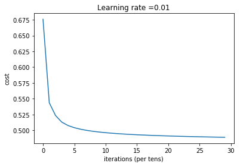

```python
# 模型搭建完毕，看看结果吧
data=GetData()
re_parameters = model(data)
```

## 完结撒花

看起来结果还行

- Train Accuracy: 0.820225
- dev Accuracy: 0.815642
- test Accuracy: 0.923445

训练集、开发集准确率稳定在 82% 左右，而测试集意外的达到了 92% 。

这个模型就是简单的单层网络，其实我还尝试了两层、三层的神经网络，但是虽然训练集、开发集准确率有所上升，但是测试集表现不佳，最低到了 79%，所以就又回到了最初的单层网络